# 🤖 Binary Classification Template — v2

### A complete, runnable scaffold for supervised binary classification projects

## How to use this notebook

1. **Read the markdown cells first** — they explain *what* each step does and *why* it's needed
2. **Search for `# ← UPDATE`** comments — these are the only places you need to change for your own dataset
3. **Run cells top-to-bottom** — later sections depend on variables defined earlier
4. The dummy dataset at the top will be automatically replaced when you load your own CSV

## The full workflow at a glance

```
1. Imports & Config
2. Load Data
3. Feature Engineering
4. Exploratory Data Analysis (EDA)
5. Train / Test Split
6. Preprocessing Pipeline
7. Helper Functions
8. Model Zoo + 5-Fold Cross-Validation
9. Hyperparameter Tuning
10. Final Test Evaluation
11. Feature Importance
12. Per-Model Confusion Matrices & ROC Curves
13. Combined ROC Curve (all models on one chart)
14. SHAP Model Interpretability
15. Conclusion & Checklist
```

> **This notebook follows the same structure as:** `07-01-machine-learning.ipynb` and `07-02-california_housing-v2_v9999.ipynb`

## Step 1 — Imports & Configuration

We import everything at the top so there are no surprises later.

**Core libraries used:**

- `numpy`, `pandas` — data handling and manipulation
- `matplotlib`, `seaborn` — visualisation
- `sklearn` — all machine learning tools (models, pipelines, metrics, etc.)
- `xgboost`, `lightgbm` — high-performance gradient boosting models

**Configuration set here:**

- Colour palette constants for confusion matrix plots (`CLR_TP`, `CLR_TN`, etc.)
- `RANDOM_STATE = 123` — used everywhere for reproducibility (same seed = same results every run)
- `warnings.filterwarnings('ignore')` — suppresses noisy sklearn / lightgbm messages

```python
import time
import warnings
import pandas as pd
import numpy as np
import matplotlib.pyplot as plt
import seaborn as sns
import sqlite3                          # ← NEW: SQL exploration

# ── Model selection utilities ──────────────────────────────────────────────────
from sklearn.model_selection import (
    train_test_split,   # split data into train / test
    StratifiedKFold,    # k-fold that preserves class ratios in every fold
    cross_validate,     # run cross-validation and collect multiple metrics
    GridSearchCV,       # exhaustive hyperparameter search
)

# ── Preprocessing ──────────────────────────────────────────────────────────────
from sklearn.preprocessing import (
    StandardScaler,         # normalise numeric features to mean=0, std=1
    OneHotEncoder,          # convert categorical text → binary columns
    LabelEncoder,           # convert target labels → integers (required by XGBoost)
    FunctionTransformer,    # wrap a custom Python function as a sklearn transformer
)
from sklearn.impute import SimpleImputer          # fill in missing values
from sklearn.feature_selection import VarianceThreshold  # drop zero-variance columns

# ── Pipeline utilities ─────────────────────────────────────────────────────────
from sklearn.pipeline import Pipeline             # chain preprocessing + model into one object
from sklearn.compose import ColumnTransformer     # apply different transforms to different columns

# ── Evaluation metrics ─────────────────────────────────────────────────────────
from sklearn.metrics import (
    accuracy_score,
    precision_score,
    recall_score,
    f1_score,
    roc_auc_score,      # area under the ROC curve — best overall metric for binary classification
    confusion_matrix,   # 2x2 table of TP / TN / FP / FN counts
    roc_curve,          # (false positive rate, true positive rate) pairs at all thresholds
    classification_report,
    precision_recall_curve,     # ← NEW: PR curve — more informative than ROC for imbalanced credit data
    average_precision_score,    # ← NEW: area under PR curve (summarises precision-recall trade-off)
)

# ── Classifiers ───────────────────────────────────────────────────────────────
from sklearn.linear_model import LogisticRegression     # linear model — great interpretable baseline
from sklearn.tree import DecisionTreeClassifier          # single decision tree — prone to overfit
from sklearn.ensemble import RandomForestClassifier      # many trees averaged — robust ensemble
from sklearn.neighbors import KNeighborsClassifier       # predicts based on nearest training examples
from xgboost import XGBClassifier                        # gradient boosting — often top performer
from lightgbm import LGBMClassifier                     # faster gradient boosting variant

# ── Global config ─────────────────────────────────────────────────────────────
warnings.filterwarnings("ignore")
RANDOM_STATE = 123  # change this to any integer; keep it fixed for reproducibility

# Seaborn styling — consistent with project EDA notebooks      # ← NEW
sns.set_theme(style="whitegrid", font_scale=1.1)               # ← NEW
plt.rcParams["figure.dpi"] = 110                                # ← NEW

# Colour palette used in confusion matrix plots
CLR_TP   = "#2ecc71"   # green  — True Positives
CLR_TN   = "#3498db"   # blue   — True Negatives
CLR_FP   = "#e74c3c"   # red    — False Positives (model said yes, truth was no)
CLR_FN   = "#f39c12"   # orange — False Negatives (model said no, truth was yes)
CLR_CURVE = "#8e44ad"  # purple — ROC curve line
CLR_DARK  = "#2c3e50"  # dark   — general accent

print("✅ Imports and configuration ready.")
```

```
✅ Imports and configuration ready.
```

## Step 2 — Load Data

Replace the dummy dataset block with your own CSV (or other source).

**After loading, always inspect:**

- `df.shape` — how many rows × columns?
- `df.dtypes` — are numeric columns typed as numbers, and text columns as `object`?
- `df.head()` — do the values look sensible?
- `df.describe()` — are ranges / means reasonable?
- `df['target'].value_counts(normalize=True)` — is the dataset class-imbalanced?

> 📌 **Unit of analysis:** What does one row represent? A person? A transaction? A time period? This matters for how you interpret features and predictions.

```python
# ─────────────────────────────────────────────────────────────────────────────
# ← UPDATE: Load the Lending Club sample CSV
# ─────────────────────────────────────────────────────────────────────────────

df = pd.read_csv("lending_club_sample.csv", low_memory=False)

# ─────────────────────────────────────────────────────────────────────────────
# Initial inspection — always run these
# ─────────────────────────────────────────────────────────────────────────────
print("Dataset shape:", df.shape)
print("\nColumn types:")
print(df.dtypes)
print("\nFirst 5 rows:")
display(df.head())
print("\nSummary statistics:")
display(df.describe())

# ─────────────────────────────────────────────────────────────────────────────
# Unit of analysis: one row = one issued loan on the Lending Club platform.
# Target: 'default' column (1 = borrower did not fully repay, 0 = fully paid).
# Default rate: ~19.4% — roughly 1 in 5 loans ended in some form of non-payment.
# ─────────────────────────────────────────────────────────────────────────────
print("\n" + "=" * 50)
print("Target variable: 'default'")
print("=" * 50)
print(df["default"].value_counts())
print("\nAs proportions:")
print(df["default"].value_counts(normalize=True).round(3))

# Sanity check: what loan statuses were mapped to each class
print("\n" + "=" * 50)
print("Loan status breakdown (original categories)")
print("=" * 50)
print(df["loan_status"].value_counts())
```

```
Dataset shape: (98277, 40)

Column types:
loan_amnt                float64
term                      object
int_rate                 float64
installment              float64
grade                     object
sub_grade                 object
emp_length                 int64
home_ownership            object
annual_inc               float64
verification_status       object
issue_d                   object
loan_status               object
purpose                   object
addr_state                object
dti                      float64
delinq_2yrs              float64
earliest_cr_line          object
fico_range_low           float64
fico_range_high          float64
inq_last_6mths           float64
open_acc                 float64
pub_rec                  float64
revol_bal                float64
revol_util               float64
total_acc                float64
application_type          object
bc_util                  float64
mort_acc                 float64
num_accts_ever_120_pd    float64
pct_tl_nvr_dlq           float64
percent_bc_gt_75         float64
pub_rec_bankruptcies     float64
default                    int64
default_label             object
term_months              float64
emp_length_yrs             int64
fico_avg                 float64
grade_num                  int64
issue_year                 int64
issue_month                int64
dtype: object

First 5 rows:
```

|  | loan_amnt | term | int_rate | installment | grade | sub_grade | emp_length | home_ownership | annual_inc | verification_status | ... | percent_bc_gt_75 | pub_rec_bankruptcies | default | default_label | term_months | emp_length_yrs | fico_avg | grade_num | issue_year | issue_month |
| --- | --- | --- | --- | --- | --- | --- | --- | --- | --- | --- | --- | --- | --- | --- | --- | --- | --- | --- | --- | --- | --- |
| 0 | 10000.0 | 36 months | 8.07 | 313.67 | A | A4 | 6 | MORTGAGE | 150000.0 | Not Verified | ... | 42.9 | 0.0 | 0 | No Default | 36.0 | 6 | 792.0 | 1 | 2007 | 11 |
| 1 | 4350.0 | 36 months | 8.07 | 136.45 | A | A4 | 0 | RENT | 120000.0 | Not Verified | ... | 42.9 | 0.0 | 0 | No Default | 36.0 | 0 | 742.0 | 1 | 2007 | 8 |
| 2 | 15600.0 | 36 months | 11.86 | 265.17 | D | D1 | 10 | MORTGAGE | 63000.0 | Not Verified | ... | 42.9 | 0.0 | 0 | No Default | 36.0 | 10 | 687.0 | 4 | 2007 | 7 |
| 3 | 16000.0 | 36 months | 10.91 | 523.14 | C | C3 | 0 | RENT | 200000.0 | Not Verified | ... | 42.9 | 0.0 | 0 | No Default | 36.0 | 0 | 697.0 | 3 | 2007 | 12 |
| 4 | 9500.0 | 36 months | 8.07 | 297.99 | A | A4 | 2 | OWN | 63000.0 | Not Verified | ... | 42.9 | 0.0 | 0 | No Default | 36.0 | 2 | 792.0 | 1 | 2007 | 9 |

5 rows × 40 columns

```
Summary statistics:
```

|  | loan_amnt | int_rate | installment | emp_length | annual_inc | dti | delinq_2yrs | fico_range_low | fico_range_high | inq_last_6mths | ... | pct_tl_nvr_dlq | percent_bc_gt_75 | pub_rec_bankruptcies | default | term_months | emp_length_yrs | fico_avg | grade_num | issue_year | issue_month |
| --- | --- | --- | --- | --- | --- | --- | --- | --- | --- | --- | --- | --- | --- | --- | --- | --- | --- | --- | --- | --- | --- |
| count | 98277.000000 | 98277.000000 | 98277.000000 | 98277.000000 | 9.827300e+04 | 98240.000000 | 98248.000000 | 98277.000000 | 98277.000000 | 98248.000000 | ... | 98277.000000 | 98277.000000 | 98277.000000 | 98277.000000 | 98277.000000 | 98277.000000 | 98277.000000 | 98277.000000 | 98277.000000 | 98277.000000 |
| mean | 13456.597424 | 13.198997 | 406.984978 | 5.832412 | 7.409901e+04 | 16.696063 | 0.257847 | 701.655219 | 705.655331 | 0.817991 | ... | 96.303162 | 44.040081 | 0.101743 | 0.194186 | 41.759883 | 5.832412 | 703.655275 | 2.736154 | 2013.542273 | 6.689347 |
| std | 8583.366232 | 4.582500 | 255.642462 | 3.721109 | 7.276149e+04 | 10.977933 | 0.774707 | 34.282294 | 34.282764 | 1.221269 | ... | 7.444885 | 29.947758 | 0.325864 | 0.395575 | 10.249976 | 3.721109 | 34.282529 | 1.333149 | 2.901102 | 3.440158 |
| min | 500.000000 | 5.310000 | 7.610000 | 0.000000 | 0.000000e+00 | -1.000000 | 0.000000 | 610.000000 | 614.000000 | 0.000000 | ... | 7.100000 | 0.000000 | 0.000000 | 0.000000 | 36.000000 | 0.000000 | 612.000000 | 1.000000 | 2007.000000 | 1.000000 |
| 25% | 6950.000000 | 9.990000 | 215.330000 | 2.000000 | 4.500000e+04 | 10.380000 | 0.000000 | 675.000000 | 679.000000 | 0.000000 | ... | 95.200000 | 25.000000 | 0.000000 | 0.000000 | 36.000000 | 2.000000 | 677.000000 | 2.000000 | 2011.000000 | 4.000000 |
| 50% | 11675.000000 | 12.790000 | 345.760000 | 6.000000 | 6.200000e+04 | 16.110000 | 0.000000 | 695.000000 | 699.000000 | 0.000000 | ... | 100.000000 | 42.900000 | 0.000000 | 0.000000 | 36.000000 | 6.000000 | 697.000000 | 3.000000 | 2014.000000 | 7.000000 |
| 75% | 18700.000000 | 15.810000 | 539.030000 | 10.000000 | 9.000000e+04 | 22.112500 | 0.000000 | 720.000000 | 724.000000 | 1.000000 | ... | 100.000000 | 60.000000 | 0.000000 | 0.000000 | 36.000000 | 10.000000 | 722.000000 | 4.000000 | 2016.000000 | 10.000000 |
| max | 40000.000000 | 30.990000 | 1715.420000 | 10.000000 | 9.300000e+06 | 999.000000 | 21.000000 | 845.000000 | 850.000000 | 33.000000 | ... | 100.000000 | 100.000000 | 8.000000 | 1.000000 | 60.000000 | 10.000000 | 847.500000 | 7.000000 | 2018.000000 | 12.000000 |

8 rows × 28 columns

```
==================================================
Target variable: 'default'
==================================================
default
0    79193
1    19084
Name: count, dtype: int64

As proportions:
default
0    0.806
1    0.194
Name: proportion, dtype: float64

==================================================
Loan status breakdown (original categories)
==================================================
loan_status
Fully Paid                                             76654
Charged Off                                            16288
Does not meet the credit policy. Status:Fully Paid      1836
Late (31-120 days)                                      1743
Does not meet the credit policy. Status:Charged Off      703
In Grace Period                                          676
Late (16-30 days)                                        373
Default                                                    4
Name: count, dtype: int64
```

```python
# ─────────────────────────────────────────────────────────────────────────────
# SQL Exploration
# Load the DataFrame into an in-memory SQLite database for SQL-based queries.
# ─────────────────────────────────────────────────────────────────────────────

conn = sqlite3.connect(":memory:")
df.to_sql("loans", conn, index=False, if_exists="replace")

# Query 1: Default rate by loan grade
print("=" * 55)
print("SQL: Default rate by loan grade")
print("=" * 55)
q1 = pd.read_sql_query("""
    SELECT grade,
           COUNT(*)                              AS total_loans,
           SUM("default")                        AS defaults,
           ROUND(AVG("default") * 100, 1)        AS default_rate_pct
    FROM loans
    GROUP BY grade
    ORDER BY grade
""", conn)
display(q1)

# Query 2: Average income and DTI by default status
print("\n" + "=" * 55)
print("SQL: Avg income & DTI by default status")
print("=" * 55)
q2 = pd.read_sql_query("""
    SELECT default_label,
           COUNT(*)                          AS n,
           ROUND(AVG(annual_inc), 0)         AS avg_income,
           ROUND(AVG(dti), 2)               AS avg_dti,
           ROUND(AVG(int_rate), 2)          AS avg_int_rate,
           ROUND(AVG(fico_avg), 1)          AS avg_fico
    FROM loans
    GROUP BY default_label
""", conn)
display(q2)

# Query 3: Top 5 loan purposes by default rate (minimum 500 loans)
print("\n" + "=" * 55)
print("SQL: Top 5 purposes by default rate (min 500 loans)")
print("=" * 55)
q3 = pd.read_sql_query("""
    SELECT purpose,
           COUNT(*)                              AS total_loans,
           ROUND(AVG("default") * 100, 1)        AS default_rate_pct
    FROM loans
    GROUP BY purpose
    HAVING COUNT(*) >= 500
    ORDER BY default_rate_pct DESC
    LIMIT 5
""", conn)
display(q3)

conn.close()
print("\n✅ SQL exploration complete.")
```

```
=======================================================
SQL: Default rate by loan grade
=======================================================
```

|  | grade | total_loans | defaults | default_rate_pct |
| --- | --- | --- | --- | --- |
| 0 | A | 18456 | 1312 | 7.1 |
| 1 | B | 28851 | 4215 | 14.6 |
| 2 | C | 25655 | 5828 | 22.7 |
| 3 | D | 14970 | 4245 | 28.4 |
| 4 | E | 6980 | 2297 | 32.9 |
| 5 | F | 2557 | 902 | 35.3 |
| 6 | G | 808 | 285 | 35.3 |

```
=======================================================
SQL: Avg income & DTI by default status
=======================================================
```

|  | default_label | n | avg_income | avg_dti | avg_int_rate | avg_fico |
| --- | --- | --- | --- | --- | --- | --- |
| 0 | Default | 19084 | 69790.0 | 18.75 | 15.42 | 694.7 |
| 1 | No Default | 79193 | 75137.0 | 16.20 | 12.66 | 705.8 |

```
=======================================================
SQL: Top 5 purposes by default rate (min 500 loans)
=======================================================
```

|  | purpose | total_loans | default_rate_pct |
| --- | --- | --- | --- |
| 0 | small_business | 2307 | 26.8 |
| 1 | medical | 1269 | 21.1 |
| 2 | debt_consolidation | 53035 | 20.7 |
| 3 | house | 788 | 20.1 |
| 4 | other | 7412 | 20.0 |

```
✅ SQL exploration complete.
```

## Step 3 — Feature Engineering

Create new features from raw columns *before* splitting. Common patterns:

| Transformation | When to use | Example |
| --- | --- | --- |
| **Ratio features** | Raw totals that depend on group size | `rooms / households` |
| **Log transform** | Right-skewed numeric features | `log1p(income)` |
| **Interaction terms** | Two features that combine non-linearly | `age × income` |
| **Binning** | Continuous → ordinal categories | `pd.cut(age, bins)` |
| **Date decomposition** | Datetime columns | `month`, `day_of_week`, `days_since` |

**If your target is continuous, binarise it here:**

```
df['target'] = np.where(df['price'] >= 500_000, 'expensive', 'affordable')
df = df.drop(columns=['price'])  # CRITICAL: drop the source column — leaving it in is data leakage!
```

> ⚠️ **Leakage rule:** Immediately drop any column that was directly used to *derive* the target. If the model can see the source, it's cheating.

```python
# ─────────────────────────────────────────────────────────────────────────────
# STEP 3 — Feature Engineering for Credit Risk
# ─────────────────────────────────────────────────────────────────────────────
# Strategy:
#   1. Create derived features that capture credit risk relationships
#   2. Drop leakage columns and columns replaced by engineered versions
#   3. Leave categorical columns as strings — the pipeline (Step 6) handles encoding
# ─────────────────────────────────────────────────────────────────────────────

# ── 3.1  Derived features ────────────────────────────────────────────────────

# installment_to_income: monthly payment as a fraction of monthly income.
# A borrower paying 30% of their monthly income on a loan instalment is much
# riskier than one paying 5%, even if the dollar amount is the same.
# Clip annual_inc at 1 to avoid division-by-zero → inf values.
df["installment_to_income"] = df["installment"] / (df["annual_inc"].clip(lower=1) / 12)

# credit_history_years: how long the borrower has had any credit line.
# Longer history → more data for lenders to assess reliability.
# We use a fixed reference date (end of the dataset's time range) so
# this feature is consistent across all loans.
df["earliest_cr_line"] = pd.to_datetime(df["earliest_cr_line"], format="%b-%Y", errors="coerce")
reference_date = pd.Timestamp("2018-12-31")
df["credit_history_years"] = (reference_date - df["earliest_cr_line"]).dt.days / 365.25

# delinquency_flag: binary — has the borrower ever been seriously late?
# Combines two noisy count variables (delinq_2yrs, num_accts_ever_120_pd)
# into a single clean yes/no signal. A bank cares whether it happened at all.
df["delinquency_flag"] = (
    (df["delinq_2yrs"] > 0) | (df["num_accts_ever_120_pd"] > 0)
).astype(int)

# log_annual_inc: log-transform of income to reduce right-skew.
# Income distributions have a long right tail (a few very high earners).
# Log compresses that tail, making the feature more normally distributed
# and easier for linear models (Logistic Regression) to work with.
df["log_annual_inc"] = np.log1p(df["annual_inc"])

# ── 3.2  Safety check: replace inf with NaN ─────────────────────────────────
# Division-based features can silently produce inf. Replace with NaN so the
# pipeline's SimpleImputer can handle them cleanly in Step 6.
num_cols_check = df.select_dtypes(include=[np.number]).columns
df[num_cols_check] = df[num_cols_check].replace([np.inf, -np.inf], np.nan)

print("New features created:")
print(df[["installment_to_income", "credit_history_years",
          "delinquency_flag", "log_annual_inc"]].describe().round(2))

# ── 3.3  Drop columns ───────────────────────────────────────────────────────
# Three categories of drops:
#   A) Leakage / post-origination columns
#   B) Columns replaced by engineered versions
#   C) High-cardinality or date columns not suitable for modelling

cols_to_drop = [
    # (A) Target-related — 'default' is our target; these are its source or label
    "loan_status",        # original text target — replaced by 'default'
    "default_label",      # text version of default — would leak the target directly

    # (B) Replaced by engineered features
    "term",               # replaced by term_months (already in CSV)
    "earliest_cr_line",   # replaced by credit_history_years (created above)
    "fico_range_low",     # replaced by fico_avg (already in CSV)
    "fico_range_high",    # replaced by fico_avg (already in CSV)
    "emp_length",         # replaced by emp_length_yrs (already in CSV)

    # (C) Dropped for modelling reasons
    "grade",              # replaced by grade_num (ordinal, already in CSV)
    "sub_grade",          # too granular (35 levels); grade_num + int_rate capture the signal
    "addr_state",         # 50 US states — too many categories for OHE, limited signal
    "issue_d",            # loan issue date — temporal leakage risk
    "issue_year",         # derived from issue date — temporal leakage
    "issue_month",        # derived from issue date — temporal leakage
]

# Only drop columns that actually exist (defensive — avoids KeyError)
cols_to_drop = [c for c in cols_to_drop if c in df.columns]
df = df.drop(columns=cols_to_drop)

print(f"\nDropped {len(cols_to_drop)} columns: {cols_to_drop}")
print(f"\n✅ Feature engineering complete. Shape: {df.shape}")
print(f"\nRemaining columns ({len(df.columns)}):")
print(list(df.columns))
```

```
New features created:
       installment_to_income  credit_history_years  delinquency_flag  \
count               98273.00              98248.00          98277.00
mean                    2.66                 20.28              0.26
std                   154.04                  7.49              0.44
min                     0.00                  3.33              0.00
25%                     0.04                 15.16              0.00
50%                     0.07                 19.16              0.00
75%                     0.10                 24.16              1.00
max                 14619.96                 73.00              1.00

       log_annual_inc
count        98273.00
mean            11.04
std              0.59
min              0.00
25%             10.71
50%             11.03
75%             11.41
max             16.05

Dropped 13 columns: ['loan_status', 'default_label', 'term', 'earliest_cr_line', 'fico_range_low', 'fico_range_high', 'emp_length', 'grade', 'sub_grade', 'addr_state', 'issue_d', 'issue_year', 'issue_month']

✅ Feature engineering complete. Shape: (98277, 31)

Remaining columns (31):
['loan_amnt', 'int_rate', 'installment', 'home_ownership', 'annual_inc', 'verification_status', 'purpose', 'dti', 'delinq_2yrs', 'inq_last_6mths', 'open_acc', 'pub_rec', 'revol_bal', 'revol_util', 'total_acc', 'application_type', 'bc_util', 'mort_acc', 'num_accts_ever_120_pd', 'pct_tl_nvr_dlq', 'per…
```

## Step 4 — Exploratory Data Analysis (EDA)

**Never fit a model on data you haven't looked at.** EDA answers four questions:

1. **Class balance** — is the target skewed? (affects metric choice)
2. **Missing values** — do we need to impute or drop?
3. **Feature distributions** — any obvious predictors? Any extreme outliers?
4. **Correlations** — are any features nearly identical (multicollinearity)?

> 🎯 A model that always predicts the majority class can score high *accuracy* while learning nothing. Always use **ROC-AUC** or **F1** as your primary metric when classes are imbalanced.

```
==================================================
4.1  Target (class) distribution
==================================================
default
0    79193
1    19084
Name: count, dtype: int64

As proportions:
default
0    0.806
1    0.194
Name: proportion, dtype: float64
```

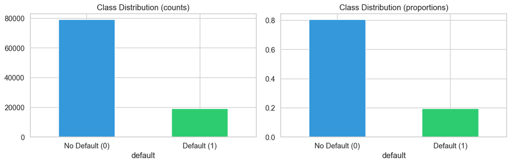

```
==================================================
4.2  Missing values (% per column)
==================================================
dti                     0.04
delinq_2yrs             0.03
inq_last_6mths          0.03
open_acc                0.03
pub_rec                 0.03
total_acc               0.03
credit_history_years    0.03
dtype: float64
```

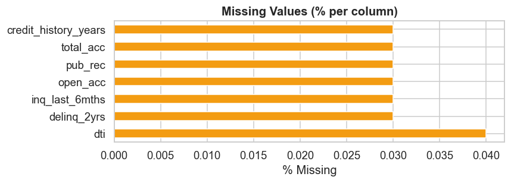

```
==================================================
4.3  Numeric feature distributions by class
==================================================
Numeric features (26): ['loan_amnt', 'int_rate', 'installment', 'annual_inc', 'dti', 'delinq_2yrs', 'inq_last_6mths', 'open_acc', 'pub_rec', 'revol_bal', 'revol_util', 'total_acc', 'bc_util', 'mort_acc', 'num_accts_ever_120_pd', 'pct_tl_nvr_dlq', 'percent_bc_gt_75', 'pub_rec_bankruptcies', 'term_mon…
Categorical features (4): ['home_ownership', 'verification_status', 'purpose', 'application_type']
```

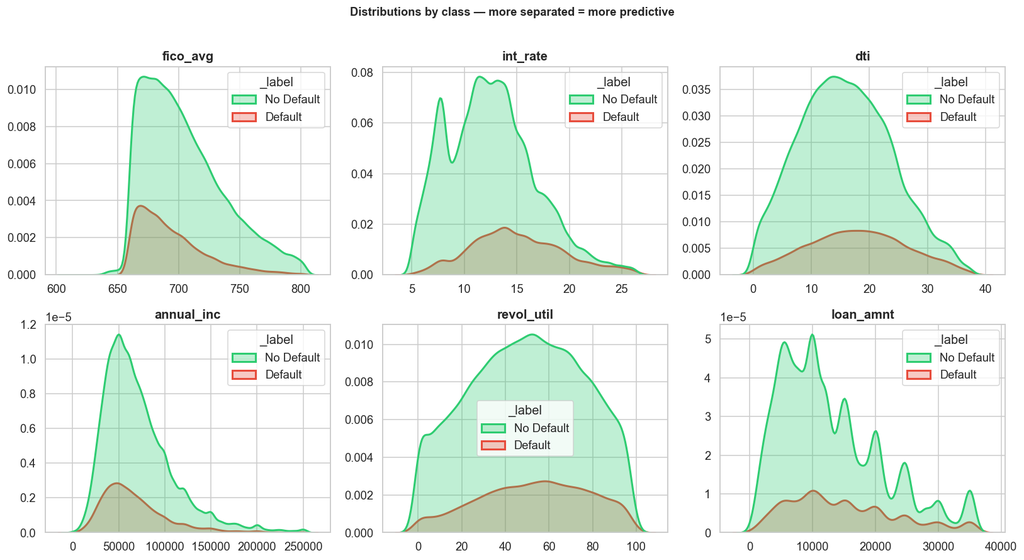

```
==================================================
4.4  Correlation matrix (Spearman, numeric features)
==================================================
```

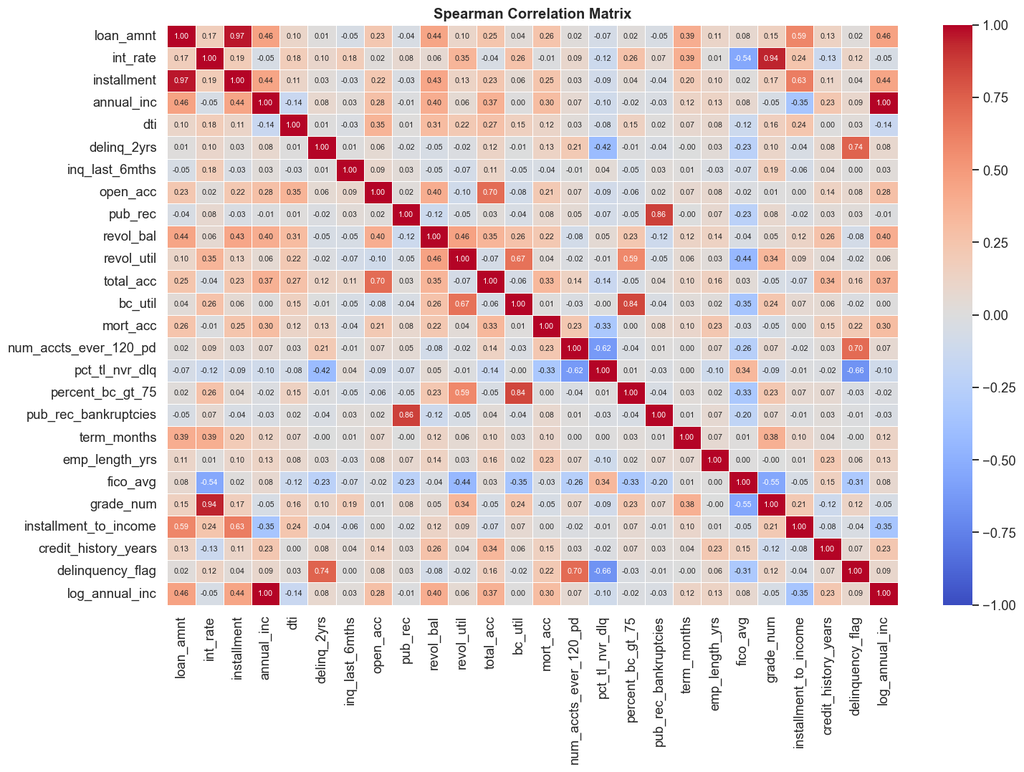

```
⚠️  Highly correlated pairs (|r| > 0.8):
    loan_amnt  ↔  installment  :  0.97
    int_rate  ↔  grade_num  :  0.94
    annual_inc  ↔  log_annual_inc  :  1.00
    pub_rec  ↔  pub_rec_bankruptcies  :  0.86
    bc_util  ↔  percent_bc_gt_75  :  0.84
```

```python
# ─────────────────────────────────────────────────────────────────────────────
# ← UPDATE: Set target column name
# ─────────────────────────────────────────────────────────────────────────────
TARGET_COL = "default"

# --- 4.1  Class distribution ---------------------------------------------------
# Shows whether classes are balanced (50/50) or imbalanced (e.g. 80/20).
# Imbalanced classes → use class_weight='balanced' in models, report AUC not accuracy.
print("=" * 50)
print("4.1  Target (class) distribution")
print("=" * 50)
print(df[TARGET_COL].value_counts())
print("\nAs proportions:")
print(df[TARGET_COL].value_counts(normalize=True).round(3))

fig, axes = plt.subplots(1, 2, figsize=(12, 4))
df[TARGET_COL].value_counts().plot(kind='bar', ax=axes[0], color=[CLR_TN, CLR_TP],
                                    title="Class Distribution (counts)", rot=0)
df[TARGET_COL].value_counts(normalize=True).plot(kind='bar', ax=axes[1], color=[CLR_TN, CLR_TP],
                                                  title="Class Distribution (proportions)", rot=0)
axes[0].set_xticklabels(["No Default (0)", "Default (1)"])
axes[1].set_xticklabels(["No Default (0)", "Default (1)"])
plt.tight_layout(); plt.show()

# --- 4.2  Missing values -------------------------------------------------------
# Tells you which columns have gaps and how many.
# Our preprocessing pipeline handles these automatically via SimpleImputer.
print("\n" + "=" * 50)
print("4.2  Missing values (% per column)")
print("=" * 50)
missing = (df.isnull().mean() * 100).round(2)
missing = missing[missing > 0].sort_values(ascending=False)
print(missing if len(missing) > 0 else "No missing values found 🎉")

if len(missing) > 0:
    fig, ax = plt.subplots(figsize=(8, max(3, len(missing) * 0.4)))
    missing.plot(kind="barh", color=CLR_FN, ax=ax)
    ax.set_title("Missing Values (% per column)", fontweight="bold")
    ax.set_xlabel("% Missing")
    plt.tight_layout(); plt.show()

# --- 4.3  Numeric feature distributions by class ------------------------------
# Plots KDE of the most important numeric features split by class.
# A feature where the two class distributions separate well → strong predictor.
numeric_cols = df.select_dtypes(include=np.number).columns.drop(TARGET_COL).tolist()
cat_cols     = df.select_dtypes(include="object").columns.tolist()

print("\n" + "=" * 50)
print("4.3  Numeric feature distributions by class")
print("=" * 50)
print(f"Numeric features ({len(numeric_cols)}): {numeric_cols}")
print(f"Categorical features ({len(cat_cols)}): {cat_cols}")

# Select the most credit-relevant numeric features for the distribution plot.
# Plotting all ~23 numerics would be unreadable — we pick the 6 most important.
key_numerics = ["fico_avg", "int_rate", "dti", "annual_inc", "revol_util", "loan_amnt"]
key_numerics = [c for c in key_numerics if c in numeric_cols]

# Create a temporary label column for plotting (not added to df permanently)
plot_label = df[TARGET_COL].map({0: "No Default", 1: "Default"})

fig, axes = plt.subplots(2, 3, figsize=(15, 8))
axes = axes.flatten()
for ax, col in zip(axes, key_numerics):
    cap = df[col].quantile(0.99)
    mask = df[col] <= cap
    sns.kdeplot(
        data=df[mask].assign(_label=plot_label[mask]),
        x=col, hue="_label",
        palette={"No Default": CLR_TP, "Default": CLR_FP},
        fill=True, alpha=0.3, linewidth=2, ax=ax,
    )
    ax.set_title(col, fontweight="bold")
    ax.set_xlabel(""); ax.set_ylabel("")
plt.suptitle("Distributions by class — more separated = more predictive",
             fontsize=12, fontweight="bold", y=1.01)
plt.tight_layout(); plt.show()

# --- 4.4  Correlation matrix --------------------------------------------------
# Spearman correlation is more robust than Pearson for skewed data.
# Pairs > ±0.8 are nearly redundant — consider dropping one.
print("\n" + "=" * 50)
print("4.4  Correlation matrix (Spearman, numeric features)")
print("=" * 50)
if len(numeric_cols) >= 2:
    corr = df[numeric_cols].corr(method="spearman")
    plt.figure(figsize=(14, 10))
    sns.heatmap(corr, annot=True, fmt=".2f", cmap="coolwarm", vmin=-1, vmax=1,
                linewidths=0.5, annot_kws={"size": 7})
    plt.title("Spearman Correlation Matrix", fontweight="bold")
    plt.tight_layout(); plt.show()

    # Flag highly correlated pairs (|r| > 0.8)
    high_corr = []
    for i in range(len(corr.columns)):
        for j in range(i + 1, len(corr.columns)):
            if abs(corr.iloc[i, j]) > 0.8:
                high_corr.append((corr.columns[i], corr.columns[j], corr.iloc[i, j]))
    if high_corr:
        print("\n⚠️  Highly correlated pairs (|r| > 0.8):")
        for c1, c2, r in high_corr:
            print(f"    {c1}  ↔  {c2}  :  {r:.2f}")
    else:
        print("\nNo feature pairs with |r| > 0.8.")
else:
    print("Need at least 2 numeric features for a correlation matrix.")
```

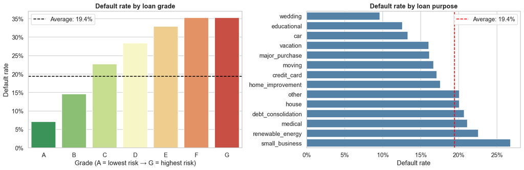

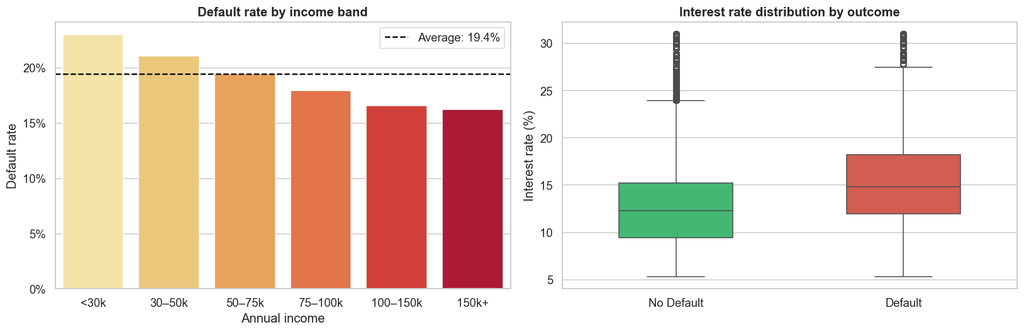

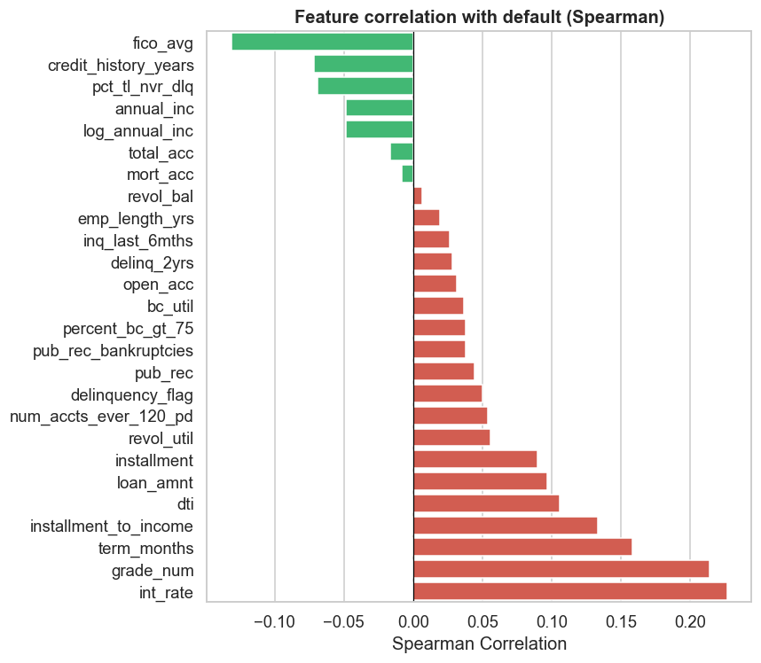

```
✅ EDA complete.
```

```python
# ─────────────────────────────────────────────────────────────────────────────
# 4.5  CREDIT-RISK-SPECIFIC VISUALISATIONS
# ─────────────────────────────────────────────────────────────────────────────
# These plots go beyond the template's generic EDA to explore patterns that
# are specifically meaningful in a credit scoring context.

average_default = df[TARGET_COL].mean()
plot_label = df[TARGET_COL].map({0: "No Default", 1: "Default"})

# --- 4.5a  Default rate by loan grade ─────────────────────────────────────────
# We reconstruct 'grade' from 'grade_num' since we dropped the text version.
grade_map_inv = {1: "A", 2: "B", 3: "C", 4: "D", 5: "E", 6: "F", 7: "G"}
grade_default = (df.assign(grade=df["grade_num"].map(grade_map_inv))
                   .groupby("grade")[TARGET_COL].mean()
                   .reindex(["A", "B", "C", "D", "E", "F", "G"])
                   .reset_index())
grade_default.columns = ["grade", "default_rate"]

fig, axes = plt.subplots(1, 2, figsize=(15, 5))

sns.barplot(data=grade_default, x="grade", y="default_rate",
            palette="RdYlGn_r", ax=axes[0])
axes[0].set_title("Default rate by loan grade", fontweight="bold")
axes[0].set_ylabel("Default rate")
axes[0].set_xlabel("Grade (A = lowest risk → G = highest risk)")
axes[0].yaxis.set_major_formatter(plt.FuncFormatter(lambda y, _: f"{y:.0%}"))
axes[0].axhline(average_default, color="black", linestyle="--", lw=1.5,
                label=f"Average: {average_default:.1%}")
axes[0].legend()

# --- 4.5b  Default rate by loan purpose ───────────────────────────────────────
purpose_default = (df.groupby("purpose")[TARGET_COL].mean()
                     .sort_values()
                     .reset_index())
purpose_default.columns = ["purpose", "default_rate"]

sns.barplot(data=purpose_default, y="purpose", x="default_rate",
            color="steelblue", ax=axes[1])
axes[1].axvline(average_default, color="red", linestyle="--", lw=1.5,
                label=f"Average: {average_default:.1%}")
axes[1].set_title("Default rate by loan purpose", fontweight="bold")
axes[1].set_xlabel("Default rate")
axes[1].set_ylabel("")
axes[1].xaxis.set_major_formatter(plt.FuncFormatter(lambda x, _: f"{x:.0%}"))
axes[1].legend()

plt.tight_layout(); plt.show()

# --- 4.5c  Default rate by income band ────────────────────────────────────────
# Bin income into meaningful bands to see how default rate changes with wealth.
income_bins  = [0, 30_000, 50_000, 75_000, 100_000, 150_000, np.inf]
income_labels = ["<30k", "30–50k", "50–75k", "75–100k", "100–150k", "150k+"]
df["income_band"] = pd.cut(df["annual_inc"], bins=income_bins, labels=income_labels)

income_default = (df.groupby("income_band", observed=True)[TARGET_COL].mean()
                    .reset_index())
income_default.columns = ["income_band", "default_rate"]

fig, axes = plt.subplots(1, 2, figsize=(15, 5))

sns.barplot(data=income_default, x="income_band", y="default_rate",
            palette="YlOrRd", ax=axes[0])
axes[0].set_title("Default rate by income band", fontweight="bold")
axes[0].set_ylabel("Default rate")
axes[0].set_xlabel("Annual income")
axes[0].yaxis.set_major_formatter(plt.FuncFormatter(lambda y, _: f"{y:.0%}"))
axes[0].axhline(average_default, color="black", linestyle="--", lw=1.5,
                label=f"Average: {average_default:.1%}")
axes[0].legend()

# --- 4.5d  Interest rate distribution by outcome ──────────────────────────────
sns.boxplot(
    data=df.assign(_label=plot_label),
    x="_label", y="int_rate",
    palette={"No Default": CLR_TP, "Default": CLR_FP},
    width=0.5, ax=axes[1],
)
axes[1].set_title("Interest rate distribution by outcome", fontweight="bold")
axes[1].set_xlabel("")
axes[1].set_ylabel("Interest rate (%)")

plt.tight_layout(); plt.show()

# --- 4.5e  Correlation with target (ranked bar chart) ─────────────────────────
# Shows which features are most predictive of default at a glance.
corr_with_target = (df[numeric_cols + [TARGET_COL]]
                      .corr(method="spearman")[TARGET_COL]
                      .drop(TARGET_COL)
                      .sort_values())

plt.figure(figsize=(8, 7))
sns.barplot(
    x=corr_with_target.values,
    y=corr_with_target.index,
    palette=[CLR_FP if v > 0 else CLR_TP for v in corr_with_target.values],
)
plt.axvline(0, color="black", linewidth=0.8)
plt.title("Feature correlation with default (Spearman)", fontweight="bold")
plt.xlabel("Spearman Correlation")
plt.ylabel("")
plt.tight_layout(); plt.show()

# ── Clean up temporary column ─────────────────────────────────────────────────
df = df.drop(columns=["income_band"])

print("\n✅ EDA complete.")
```

## Step 5 — Train / Test Split

We split the data **before any preprocessing**. This is critical:

```
1. Split  →  2. Fit preprocessor on train only  →  3. Transform train
                                                  →  4. Transform test (using train statistics)
```

If you fit the scaler or imputer on the *full* dataset before splitting, your training set "sees" test statistics — this is **data leakage** and inflates performance estimates.

**Key parameters:**

- `test_size=0.20` — 80% train, 20% test (adjust for very small/large datasets)
- `stratify=y` — ensures both splits have the same class ratio. Always use this for imbalanced targets.
- `random_state=RANDOM_STATE` — same split every run

```python
# Separate features (X) from the target (y)
X = df.drop(columns=[TARGET_COL])  # everything except the target
y = df[TARGET_COL]                  # only the target column

# Re-detect column types on features (excluding the target)
numeric_cols = X.select_dtypes(include=np.number).columns.tolist()
cat_cols     = X.select_dtypes(include="object").columns.tolist()

print(f"Numeric features  ({len(numeric_cols)}): {numeric_cols}")
print(f"Categorical features ({len(cat_cols)}): {cat_cols}")

# ── Split ─────────────────────────────────────────────────────────────────────
X_train, X_test, y_train, y_test = train_test_split(
    X, y,
    test_size=0.20,
    random_state=RANDOM_STATE,
    stratify=y,
)

# ── Encode target to integers (required by XGBoost / LightGBM) ────────────────
le = LabelEncoder()
y_train_enc = le.fit_transform(y_train)
y_test_enc  = le.transform(y_test)

print(f"\nClass mapping: {dict(zip(le.classes_, le.transform(le.classes_)))}")
print(f"\nTrain size: {X_train.shape[0]:,} rows  |  Test size: {X_test.shape[0]:,} rows")
print(f"Train class ratio: {pd.Series(y_train_enc).value_counts(normalize=True).round(3).to_dict()}")
print(f"Test  class ratio: {pd.Series(y_test_enc ).value_counts(normalize=True).round(3).to_dict()}")
```

```
Numeric features  (26): ['loan_amnt', 'int_rate', 'installment', 'annual_inc', 'dti', 'delinq_2yrs', 'inq_last_6mths', 'open_acc', 'pub_rec', 'revol_bal', 'revol_util', 'total_acc', 'bc_util', 'mort_acc', 'num_accts_ever_120_pd', 'pct_tl_nvr_dlq', 'percent_bc_gt_75', 'pub_rec_bankruptcies', 'term_mo…
Categorical features (4): ['home_ownership', 'verification_status', 'purpose', 'application_type']

Class mapping: {np.int64(0): np.int64(0), np.int64(1): np.int64(1)}

Train size: 78,621 rows  |  Test size: 19,656 rows
Train class ratio: {0: 0.806, 1: 0.194}
Test  class ratio: {0: 0.806, 1: 0.194}
```

## Step 6 — Preprocessing Pipeline

We build a `Pipeline` for each feature type, then combine them in a `ColumnTransformer`.

**Numeric pipeline:** `SimpleImputer` → `VarianceThreshold` → `StandardScaler`

- *Imputer*: fills missing values with the median (robust to outliers)
- *VarianceThreshold*: drops columns with zero variance (constant columns are useless)
- *StandardScaler*: normalises to mean=0, std=1 (essential for Logistic Regression and KNN)

**Categorical pipeline:** `SimpleImputer` → rare-category collapser → `OneHotEncoder`

**Why Pipeline instead of manual transforms?**

- ✅ No leakage — scaler is fitted only on the current training fold during cross-validation
- ✅ Single `.fit()` / `.predict()` call
- ✅ Deployment-ready — the whole object can be pickled

```python
# ── Custom helper: collapse rare categorical values ────────────────────────────
# Categories that appear in < threshold of rows are merged into 'Other'.
# Without this, OneHotEncoder creates many near-empty columns that add noise.
RARE_THRESHOLD = 0.01  # ← 1% — keeps small_business, car, medical as separate categories

def collapse_rare_categories(X_df, threshold=RARE_THRESHOLD):
    """Replace categories with frequency < threshold with 'Other'."""
    out = X_df.copy()
    for col in out.columns:
        counts = out[col].value_counts(normalize=True)
        rare   = counts[counts < threshold].index
        out[col] = out[col].apply(lambda x: "Other" if x in rare else x)
    return out

# Wrap the function so sklearn can use it inside a Pipeline
rare_collapser = FunctionTransformer(
    lambda X: collapse_rare_categories(pd.DataFrame(X, columns=cat_cols)),
    validate=False,
)

# ── Numeric sub-pipeline ──────────────────────────────────────────────────────
num_pipe = Pipeline([
    ("impute", SimpleImputer(strategy="median")),     # fill NaNs with median
    ("zv",     VarianceThreshold(threshold=0)),        # drop zero-variance columns
    ("scale",  StandardScaler()),                      # normalise
])

# ── Categorical sub-pipeline ──────────────────────────────────────────────────
cat_pipe = Pipeline([
    ("impute", SimpleImputer(strategy="most_frequent")),     # fill NaNs with mode
    ("rare",   rare_collapser),                              # merge tiny categories
    ("ohe",    OneHotEncoder(
                   handle_unknown="ignore",   # unknown test categories → all zeros
                   sparse_output=False,       # return dense array
                   drop="first",              # avoid dummy variable trap
              )),
])

# ── Combine into one ColumnTransformer ────────────────────────────────────────
# Applies num_pipe to numeric columns and cat_pipe to categorical columns in parallel.
preprocessor = ColumnTransformer([
    ("num", num_pipe, numeric_cols),
    ("cat", cat_pipe, cat_cols),
])

print("✅ Preprocessing pipeline ready.")
print(f"\nNumeric pipeline:     {len(numeric_cols)} features → impute (median) → drop zero-variance → scale")
print(f"Categorical pipeline: {len(cat_cols)} features → impute (mode) → collapse rare (<{RARE_THRESHOLD:.0%}) → one-hot encode")
print(f"\nCategorical columns: {cat_cols}")
```

```
✅ Preprocessing pipeline ready.

Numeric pipeline:     26 features → impute (median) → drop zero-variance → scale
Categorical pipeline: 4 features → impute (mode) → collapse rare (<1%) → one-hot encode

Categorical columns: ['home_ownership', 'verification_status', 'purpose', 'application_type']
```

## Step 7 — Helper Functions

We define reusable plotting functions **once** here, then call them for every model. Consistent plots make it easy to compare models visually.

```python
def plot_feature_importance(pipeline, top_n=15):
    """
    Extract and plot the top N feature importances from a fitted sklearn Pipeline.
    Handles the case where VarianceThreshold drops columns inside the numeric sub-pipeline.
    """
    pre = pipeline.named_steps["pre"]
    clf = pipeline.named_steps["clf"]

    # ── Get feature names, accounting for VarianceThreshold ──────────────────
    feature_names = []

    for trans_name, trans_pipe, cols in pre.transformers_:
        if trans_name == "num":
            # Get the boolean mask from VarianceThreshold (which columns survived)
            vt = trans_pipe.named_steps["zv"]
            mask = vt.get_support()
            survived = [c for c, keep in zip(cols, mask) if keep]
            feature_names.extend(survived)
        elif trans_name == "cat":
            # OHE feature names already reflect only the categories that were encoded
            try:
                ohe_names = trans_pipe.named_steps["ohe"].get_feature_names_out(cols)
                feature_names.extend(ohe_names)
            except Exception:
                ohe_names = trans_pipe.named_steps["ohe"].get_feature_names_out()
                feature_names.extend(ohe_names)

    # ── Get importance values ────────────────────────────────────────────────
    if hasattr(clf, "feature_importances_"):
        importances  = clf.feature_importances_
        metric_label = "Feature Importance"
    elif hasattr(clf, "coef_"):
        importances  = np.abs(clf.coef_[0])
        metric_label = "Absolute Coefficient"
    else:
        print(f"⚠️  Feature importance not supported for {clf.__class__.__name__}")
        return

    # Safety check
    if len(feature_names) != len(importances):
        print(f"⚠️  Name/importance length mismatch: {len(feature_names)} names vs {len(importances)} importances")
        feature_names = [f"Feature_{i}" for i in range(len(importances))]

    # ── Build DataFrame and plot ─────────────────────────────────────────────
    imp_df = pd.DataFrame({"Feature": feature_names, "Importance": importances})
    imp_df["Feature"] = imp_df["Feature"].str.split("__").str[-1]
    imp_df = imp_df.sort_values("Importance", ascending=True).tail(top_n)

    plt.figure(figsize=(10, 6))
    plt.barh(imp_df["Feature"], imp_df["Importance"], color=CLR_TN)
    plt.title(f"Top {top_n} {metric_label}s — {clf.__class__.__name__}",
              fontweight="bold")
    plt.xlabel(metric_label)
    plt.tight_layout()
    plt.show()


print("✅ plot_feature_importance function updated.")
```

```
✅ plot_feature_importance function updated.
```

## Step 8 — Model Zoo + 5-Fold Cross-Validation

### 8.1 Why start with multiple models?

Different algorithms have different strengths. We run all of them first with default settings so we know which family is worth tuning.

| Algorithm | Family | Needs scaling? | Notes |
| --- | --- | --- | --- |
| Logistic Regression | Linear | ✅ Yes | Interpretable, fast, strong baseline |
| Decision Tree | Tree | ❌ No | Easy to visualise but overfits |
| **Random Forest** | Ensemble (Bagging) | ❌ No | Robust, rarely overfits badly |
| **XGBoost** | Ensemble (Boosting) | ❌ No | Often the top performer |
| **LightGBM** | Ensemble (Boosting) | ❌ No | Faster than XGBoost on large data |
| KNN | Instance-based | ✅ Yes | Slow on large data, good reference |

### 8.2 Why 5-fold cross-validation instead of a single train/val split?

A single split gives **one noisy estimate**. With 5-fold CV:

- Every observation is in the *test* set exactly once
- We average 5 estimates → much more stable performance number
- We can also look at the standard deviation to detect unstable models

**Primary metric:** `roc_auc` — threshold-agnostic, insensitive to class imbalance  
**Secondary metric:** `f1_weighted` — threshold-dependent (at 0.5), accounts for class frequency

```
✅ 6 baseline models defined.
   XGBoost scale_pos_weight = 4.15

Running 5-fold CV for each model (this may take ~30 seconds)...
  [✓] Logistic Regression    AUC=0.7012 (±0.0043)  Gini=0.4024
  [✓] Decision Tree          AUC=0.5476 (±0.0047)  Gini=0.0951
  [✓] Random Forest          AUC=0.7009 (±0.0055)  Gini=0.4018
  [✓] KNN                    AUC=0.6113 (±0.0054)  Gini=0.2226
  [✓] XGBoost                AUC=0.6963 (±0.0062)  Gini=0.3926
  [✓] LightGBM               AUC=0.7164 (±0.0034)  Gini=0.4328

=================================================================
CV RESULTS (BASELINE, 5-FOLD, SORTED BY AUC)
=================================================================
              Model  Mean AUC  Std AUC  Mean F1   Gini
           LightGBM    0.7164   0.0034   0.6918 0.4328
Logistic Regression    0.7012   0.0043   0.6901 0.4024
      Random Forest    0.7009   0.0055   0.7275 0.4018
            XGBoost    0.6963   0.0062   0.7112 0.3926
                KNN    0.6113   0.0054   0.7408 0.2226
      Decision Tree    0.5476   0.0047   0.7161 0.0951
```

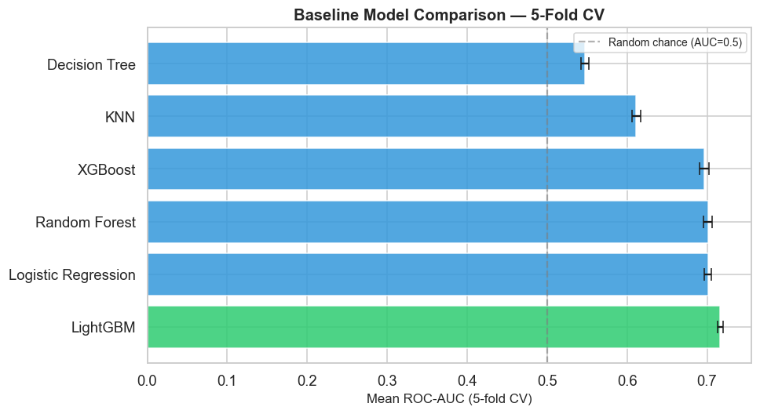

```python
# ── Define the model zoo ──────────────────────────────────────────────────────
# All models use the same RANDOM_STATE for reproducibility.
# class_weight='balanced' added to LR and RF to handle the ~80/20 imbalance.
models = {
    "Logistic Regression": LogisticRegression(
        max_iter=1000, random_state=RANDOM_STATE, class_weight="balanced",
    ),
    "Decision Tree": DecisionTreeClassifier(
        random_state=RANDOM_STATE, class_weight="balanced",
    ),
    "Random Forest": RandomForestClassifier(
        n_estimators=100, random_state=RANDOM_STATE, n_jobs=-1, class_weight="balanced",
    ),
    "KNN": KNeighborsClassifier(n_neighbors=5),
    "XGBoost": XGBClassifier(
        eval_metric="logloss", random_state=RANDOM_STATE,
        scale_pos_weight=(y_train_enc == 0).sum() / (y_train_enc == 1).sum(),
    ),
    "LightGBM": LGBMClassifier(
        random_state=RANDOM_STATE, verbose=-1, is_unbalance=True,
    ),
}
print(f"✅ {len(models)} baseline models defined.")
print(f"   XGBoost scale_pos_weight = {(y_train_enc == 0).sum() / (y_train_enc == 1).sum():.2f}")

# ── 5-fold stratified cross-validation ───────────────────────────────────────
# StratifiedKFold ensures each fold has the same class ratio as the full dataset.
cv5 = StratifiedKFold(n_splits=5, shuffle=True, random_state=RANDOM_STATE)
cv_results = []

print("\nRunning 5-fold CV for each model (this may take ~30 seconds)...")
for name, clf in models.items():
    # Wrap preprocessor + model into a single Pipeline.
    # This ensures the preprocessor is refit on each training fold, preventing leakage.
    pipe = Pipeline([("pre", preprocessor), ("clf", clf)])

    cv_scores = cross_validate(
        pipe,
        X_train,
        y_train_enc,
        cv=cv5,
        scoring=["roc_auc", "f1_weighted"],
        n_jobs=-1,   # use all CPU cores
    )

    cv_results.append({
        "Model":    name,
        "Mean AUC": cv_scores["test_roc_auc"].mean(),
        "Std AUC":  cv_scores["test_roc_auc"].std(),
        "Mean F1":  cv_scores["test_f1_weighted"].mean(),
        "Gini":     2 * cv_scores["test_roc_auc"].mean() - 1,
    })
    print(f"  [✓] {name:<22} AUC={cv_scores['test_roc_auc'].mean():.4f} "
          f"(±{cv_scores['test_roc_auc'].std():.4f})  "
          f"Gini={2 * cv_scores['test_roc_auc'].mean() - 1:.4f}")

results_df = pd.DataFrame(cv_results).sort_values("Mean AUC", ascending=False)

print("\n" + "=" * 65)
print("CV RESULTS (BASELINE, 5-FOLD, SORTED BY AUC)")
print("=" * 65)
print(results_df.round(4).to_string(index=False))

# Visualise as a bar chart with error bars (std deviation across folds)
fig, ax = plt.subplots(figsize=(9, 5))
colors = [CLR_TP if i == 0 else CLR_TN for i in range(len(results_df))]
ax.barh(results_df["Model"], results_df["Mean AUC"],
        xerr=results_df["Std AUC"], align="center", color=colors,
        alpha=0.85, capsize=5)
ax.set_xlabel("Mean ROC-AUC (5-fold CV)", fontsize=11)
ax.set_title("Baseline Model Comparison — 5-Fold CV", fontweight="bold")
ax.axvline(0.5, linestyle="--", color="gray", alpha=0.6, label="Random chance (AUC=0.5)")
ax.legend(fontsize=9)
plt.tight_layout(); plt.show()
```

## Step 9 — Hyperparameter Tuning

**Key hyperparameters explained:**

| Parameter | Model | What it controls |
| --- | --- | --- |
| `C` | Logistic Regression | Regularisation strength — small C → more regularised |
| `n_estimators` | RF / XGBoost | Number of trees — more = slower but smoother |
| `max_depth` | RF / XGBoost | Maximum tree depth — lower = less overfit |
| `learning_rate` | XGBoost | Step size per tree — smaller = more trees needed |
| `min_samples_split` | Random Forest | Min samples to split a node — higher = more regularised |

> ⚠️ Always tune with `scoring='roc_auc'`, not `'accuracy'`. Using accuracy as the tuning objective optimises for the majority class and gives misleading results on imbalanced data.

```python
# ← UPDATE: Tuning configs for the top models from CV results.
# All 4 models are tuned: LR and RF (required by brief), XGBoost and LightGBM (top performers).

tuning_configs = {
    "LogisticRegression": {
        "model": LogisticRegression(
            random_state=RANDOM_STATE, class_weight="balanced", max_iter=1000,
        ),
        "params": {
            "clf__C":       [0.01, 0.1, 1, 10],    # regularisation — lower = stronger penalty
            "clf__penalty": ["l2"],                  # L2 is standard; keeps all features
            "clf__solver":  ["lbfgs"],               # robust default solver
        },
    },
    "RandomForest": {
        "model": RandomForestClassifier(
            random_state=RANDOM_STATE, class_weight="balanced", n_jobs=-1,
        ),
        "params": {
            "clf__n_estimators":      [100, 200],       # more trees = more stable
            "clf__max_depth":         [5, 10, None],    # None = unlimited depth
            "clf__min_samples_split": [2, 5, 10],       # higher = more regularised
        },
    },
    "XGBoost": {
        "model": XGBClassifier(
            random_state=RANDOM_STATE, eval_metric="logloss",
            scale_pos_weight=(y_train_enc == 0).sum() / (y_train_enc == 1).sum(),
        ),
        "params": {
            "clf__n_estimators":  [100, 200],
            "clf__learning_rate": [0.05, 0.1],       # smaller = more conservative, less overfit
            "clf__max_depth":     [3, 5, 7],          # shallower trees reduce overfitting
        },
    },
    "LightGBM": {
        "model": LGBMClassifier(
            random_state=RANDOM_STATE, verbose=-1, is_unbalance=True,
        ),
        "params": {
            "clf__n_estimators":  [100, 200, 300],
            "clf__learning_rate": [0.05, 0.1],
            "clf__max_depth":     [3, 5, 7],
            "clf__num_leaves":    [31, 63],           # LightGBM-specific: controls tree complexity
        },
    },
}

tuning_results = []
grid_objects   = {}  # store fitted GridSearchCV objects for later

print("Starting Grid Search across 4 models...")
print("=" * 55)
for name, config in tuning_configs.items():
    tuning_pipeline = Pipeline([("pre", preprocessor), ("clf", config["model"])])

    grid_search = GridSearchCV(
        tuning_pipeline,
        config["params"],
        cv=cv5,
        scoring="roc_auc",   # ← always use AUC for binary classification tuning
        n_jobs=-1,
        verbose=0,
    )

    start_t = time.time()
    grid_search.fit(X_train, y_train_enc)
    elapsed = time.time() - start_t

    grid_objects[name] = grid_search
    gini = 2 * grid_search.best_score_ - 1
    tuning_results.append({
        "Model":       name,
        "Best AUC":    grid_search.best_score_,
        "Gini":        gini,
        "Time (s)":    round(elapsed, 1),
        "Best Params": grid_search.best_params_,
    })
    print(f"[✓] {name:<22} {elapsed:>5.1f}s  |  Best CV AUC: {grid_search.best_score_:.4f}  Gini: {gini:.4f}")
    print(f"    Best params: {grid_search.best_params_}")

# Identify the overall best model
best_model_name = sorted(tuning_results, key=lambda x: x["Best AUC"], reverse=True)[0]["Model"]
best_pipeline   = grid_objects[best_model_name].best_estimator_  # already fitted

print(f"\n{'=' * 55}")
print(f"🏆 Best model overall: {best_model_name}")
print(f"   AUC = {grid_objects[best_model_name].best_score_:.4f}")
print(f"   Gini = {2 * grid_objects[best_model_name].best_score_ - 1:.4f}")
```

```
Starting Grid Search across 4 models...
=======================================================
[✓] LogisticRegression       9.5s  |  Best CV AUC: 0.7012  Gini: 0.4024
    Best params: {'clf__C': 10, 'clf__penalty': 'l2', 'clf__solver': 'lbfgs'}
[✓] RandomForest           354.7s  |  Best CV AUC: 0.7115  Gini: 0.4231
    Best params: {'clf__max_depth': None, 'clf__min_samples_split': 10, 'clf__n_estimators': 200}
[✓] XGBoost                 40.6s  |  Best CV AUC: 0.7175  Gini: 0.4349
    Best params: {'clf__learning_rate': 0.05, 'clf__max_depth': 5, 'clf__n_estimators': 200}
[✓] LightGBM               180.6s  |  Best CV AUC: 0.7181  Gini: 0.4363
    Best params: {'clf__learning_rate': 0.05, 'clf__max_depth': 7, 'clf__n_estimators': 200, 'clf__num_leaves': 31}

=======================================================
🏆 Best model overall: LightGBM
   AUC = 0.7181
   Gini = 0.4363
```

## Step 10 — Final Evaluation on the Test Set

**This is the moment of truth.**  
Everything so far (CV, tuning) was done on training data. The test set has **never been seen by any model**.

We evaluate the best tuned model on the held-out test set and report six metrics:

| Metric | When it matters most |
| --- | --- |
| **Accuracy** | Balanced classes only |
| **Precision** | Cost of false alarms is high (e.g. spam detection) |
| **Recall** | Cost of missing positives is high (e.g. cancer screening) |
| **F1-Score** | Need to balance precision and recall |
| **ROC-AUC** | Always — threshold-agnostic ranking metric |
| **Classification report** | Full breakdown per class |

> 💡 A gap between CV score and test score is normal. A *large* gap (> 5 AUC points) suggests the model overfit — consider more regularisation.

```
=======================================================
TEST SET RESULTS — LightGBM
=======================================================
Accuracy:  0.6625
Precision: 0.3182
Recall:    0.6458
F1-Score:  0.4263
ROC-AUC:   0.7159
Gini:      0.4319

Full Classification Report:
              precision    recall  f1-score   support

           0       0.89      0.67      0.76     15839
           1       0.32      0.65      0.43      3817

    accuracy                           0.66     19656
   macro avg       0.60      0.66      0.59     19656
weighted avg       0.78      0.66      0.70     19656
```

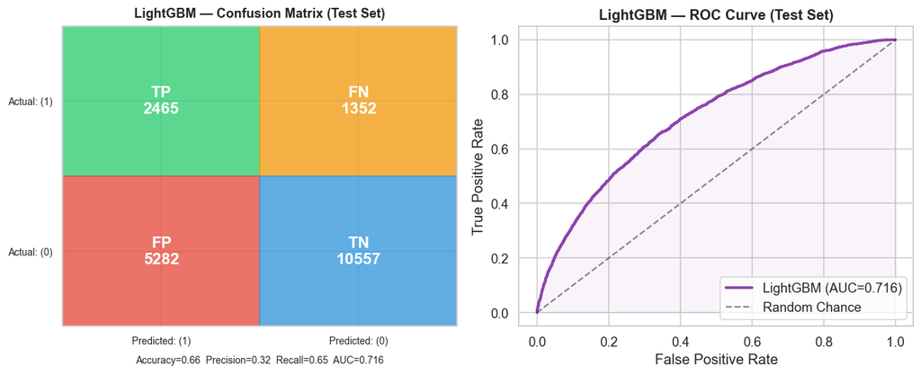

```
=======================================================
CREDIT RISK INTERPRETATION
=======================================================
Total test loans:     19,656
Actual defaults:      3,817  (19.4%)
Actual non-defaults:  15,839  (80.6%)

✅ True Positives  (TP = 2,465): Correctly flagged as default → bad loan avoided
✅ True Negatives  (TN = 10,557): Correctly approved → earned interest income
⚠️  False Positives (FP = 5,282): Good borrower rejected → lost revenue (cost: interest margin)
🚨 False Negatives (FN = 1,352): Default approved → lost principal (cost: outstanding balance)

Default detection rate (Recall):  2465/3817 = 64.6%
Precision on defaults:            2465/7747 = 31.8%

Business trade-off:
  - We catch 65% of defaults (saved the bank from 2,465 bad loans)
  - But we also reject 5,282 good borrowers who would have repaid
  - 1,352 defaults slip through undetected — these are the most costly errors
  - Lowering the threshold below 0.5 would catch more defaults but reject more good borrowers
```

```python
print("=" * 55)
print(f"TEST SET RESULTS — {best_model_name}")
print("=" * 55)

# Generate predictions on the untouched test set
y_pred  = best_pipeline.predict(X_test)          # hard predictions (0 or 1)
y_proba = best_pipeline.predict_proba(X_test)[:, 1]  # probability of class 1

# Compute and print metrics
test_auc = roc_auc_score(y_test_enc, y_proba)
print(f"Accuracy:  {accuracy_score(y_test_enc, y_pred):.4f}")
print(f"Precision: {precision_score(y_test_enc, y_pred, zero_division=0):.4f}")
print(f"Recall:    {recall_score(y_test_enc, y_pred, zero_division=0):.4f}")
print(f"F1-Score:  {f1_score(y_test_enc, y_pred, zero_division=0):.4f}")
print(f"ROC-AUC:   {test_auc:.4f}")
print(f"Gini:      {2 * test_auc - 1:.4f}")
print("\nFull Classification Report:")
print(classification_report(y_test_enc, y_pred, zero_division=0))

# Confusion matrix for the best model
fig, axes = plt.subplots(1, 2, figsize=(12, 5))

plot_confusion_matrix(
    ax=axes[0],
    y_true=y_test_enc,
    y_pred=y_pred,
    title=f"{best_model_name} — Confusion Matrix (Test Set)",
    y_proba=y_proba,
)

plot_roc_curve(axes[1], y_test_enc, y_proba, best_model_name)
axes[1].plot([0, 1], [0, 1], "k--", alpha=0.5, label="Random Chance")
axes[1].set_title(f"{best_model_name} — ROC Curve (Test Set)", fontweight="bold")
axes[1].set_xlabel("False Positive Rate"); axes[1].set_ylabel("True Positive Rate")
axes[1].legend(loc="lower right")

plt.tight_layout(); plt.show()

# ── Credit risk interpretation ────────────────────────────────────────────────
cm = confusion_matrix(y_test_enc, y_pred)
TN, FP, FN, TP = cm.ravel()
total_defaults     = TP + FN
total_non_defaults = TN + FP

print("=" * 55)
print("CREDIT RISK INTERPRETATION")
print("=" * 55)
print(f"Total test loans:     {len(y_test_enc):,}")
print(f"Actual defaults:      {total_defaults:,}  ({total_defaults/len(y_test_enc):.1%})")
print(f"Actual non-defaults:  {total_non_defaults:,}  ({total_non_defaults/len(y_test_enc):.1%})")
print()
print(f"✅ True Positives  (TP = {TP:,}): Correctly flagged as default → bad loan avoided")
print(f"✅ True Negatives  (TN = {TN:,}): Correctly approved → earned interest income")
print(f"⚠️  False Positives (FP = {FP:,}): Good borrower rejected → lost revenue (cost: interest margin)")
print(f"🚨 False Negatives (FN = {FN:,}): Default approved → lost principal (cost: outstanding balance)")
print()
print(f"Default detection rate (Recall):  {TP}/{total_defaults} = {recall_score(y_test_enc, y_pred):.1%}")
print(f"Precision on defaults:            {TP}/{TP+FP} = {precision_score(y_test_enc, y_pred):.1%}")
print()
print("Business trade-off:")
print(f"  - We catch {recall_score(y_test_enc, y_pred):.0%} of defaults (saved the bank from {TP:,} bad loans)")
print(f"  - But we also reject {FP:,} good borrowers who would have repaid")
print(f"  - {FN:,} defaults slip through undetected — these are the most costly errors")
print(f"  - Lowering the threshold below 0.5 would catch more defaults but reject more good borrowers")
```

## Step 11 — Feature Importance

Feature importance tells us **which inputs the model relied on most**.

- **Tree models** (Random Forest, XGBoost): `.feature_importances_` — how much each feature reduced impurity
- **Linear models** (Logistic Regression): `abs(coef_)` — how much each feature shifts the log-odds

> ⚠️ **Caveat:** Importance shows *which* features matter, not *in what direction*. Use SHAP (Step 14) for directional interpretation.

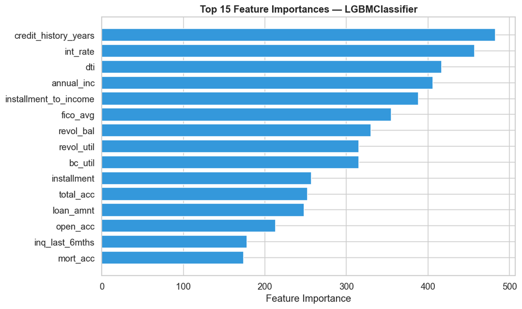

```python
# Plot top 15 most important features for the best tuned model
plot_feature_importance(best_pipeline, top_n=15)
```

## Step 12 — Confusion Matrices & ROC Curves for All Models

We refit all baseline models on the full training set and evaluate each on the test set. This gives a side-by-side visual comparison of every model's error profile.

```
Fitting all baseline models on training data and plotting test-set results...
```

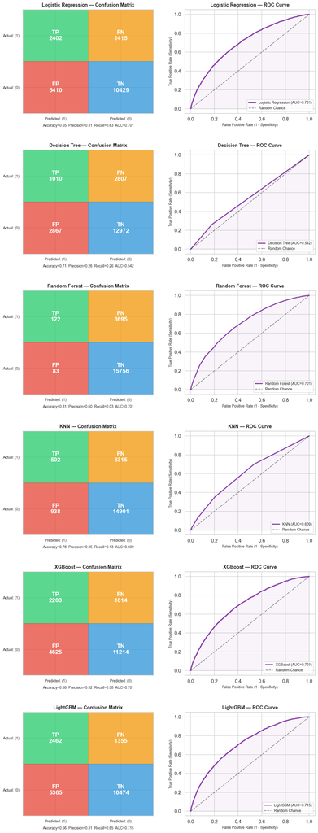

```python
print("Fitting all baseline models on training data and plotting test-set results...")

num_models = len(models)
fig, axes  = plt.subplots(nrows=num_models, ncols=2, figsize=(12, 5 * num_models))

# Ensure axes is always 2D (handles the edge case of 1 model)
if num_models == 1:
    axes = [axes]

for i, (name, clf) in enumerate(models.items()):
    # Build a fresh pipeline for this model and fit it
    pipe = Pipeline([("pre", preprocessor), ("clf", clf)])
    pipe.fit(X_train, y_train_enc)

    # Generate test-set predictions
    y_pred_i  = pipe.predict(X_test)
    y_proba_i = pipe.predict_proba(X_test)[:, 1]

    # ── Left column: Confusion Matrix ─────────────────────────────────────────
    plot_confusion_matrix(
        ax=axes[i][0],
        y_true=y_test_enc,
        y_pred=y_pred_i,
        title=f"{name} — Confusion Matrix",
        y_proba=y_proba_i,
    )

    # ── Right column: ROC Curve ───────────────────────────────────────────────
    plot_roc_curve(axes[i][1], y_true=y_test_enc, y_proba=y_proba_i, model_name=name)
    axes[i][1].plot([0, 1], [0, 1], "k--", alpha=0.5, label="Random Chance")
    axes[i][1].set_title(f"{name} — ROC Curve", fontsize=12, fontweight="bold", pad=8)
    axes[i][1].set_xlabel("False Positive Rate (1 - Specificity)", fontsize=9)
    axes[i][1].set_ylabel("True Positive Rate (Sensitivity)", fontsize=9)
    axes[i][1].legend(loc="lower right", fontsize=9)

plt.tight_layout(pad=3.0)
plt.show()
```

## Step 13 — Combined ROC Curve (All Models)

Overlaying all models on a single ROC plot makes it easy to see which model dominates at every threshold — not just at 0.5. The closer a curve hugs the top-left corner, the better.

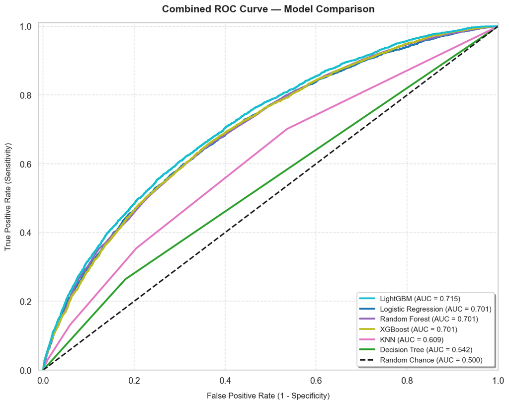

```python
plt.figure(figsize=(10, 8))
ax = plt.gca()

# Assign a distinct colour to each model
colors = plt.cm.tab10(np.linspace(0, 1, len(models)))

for (name, clf), color in zip(models.items(), colors):
    # Refit fresh pipeline — reusing pipes from Step 12 would also work,
    # but we rebuild here to keep this cell self-contained.
    pipe = Pipeline([("pre", preprocessor), ("clf", clf)])
    pipe.fit(X_train, y_train_enc)

    y_proba_i = pipe.predict_proba(X_test)[:, 1]
    fpr, tpr, _ = roc_curve(y_test_enc, y_proba_i)
    auc = roc_auc_score(y_test_enc, y_proba_i)

    ax.plot(fpr, tpr, lw=2.5, color=color, label=f"{name} (AUC = {auc:.3f})")

# Diagonal line = random guessing (AUC = 0.5)
ax.plot([0, 1], [0, 1], "k--", lw=2, label="Random Chance (AUC = 0.500)")

ax.set_title("Combined ROC Curve — Model Comparison", fontsize=14, fontweight="bold", pad=15)
ax.set_xlabel("False Positive Rate (1 - Specificity)", fontsize=11, labelpad=10)
ax.set_ylabel("True Positive Rate (Sensitivity)", fontsize=11, labelpad=10)
ax.set_xlim([-0.01, 1.0]); ax.set_ylim([0.0, 1.01])

# Sort legend entries by AUC (highest first)
handles, labels = ax.get_legend_handles_labels()
hl = sorted(zip(handles, labels), key=lambda x: x[1].split("=")[-1], reverse=True)
handles_sorted, labels_sorted = zip(*hl)
ax.legend(handles_sorted, labels_sorted, loc="lower right", fontsize=10, frameon=True, shadow=True)

ax.grid(True, linestyle="--", alpha=0.6)
plt.tight_layout()
plt.show()
```